# Research Computing Bootcamp

Boston University

## R Track: Part 3 - Data Visualization in R

Examining complex patterns and correlations in data requires visualization to present the results in a digestible form. Part Three presents various ways to plot and visualize data. Different plotting techniques and formats are presented, along with various ways to format and configure their display and appearance.

R plotting libraries are designed to produce high-quality graphics.

Various types of plots allow to generate plots of:

- a single variable
- two variables
- multiple variables
- networks
- time series
- many other special plots

First, we need to load the packages that we will use for this workshop"

```r
library(readr)
library(ggplot2)
library(dplyr)
```

Let’s read the two dataset we explored in the previous workshop and merg them together:

```r
NE.health <- read_csv("https://github.com/bu-rcs/bu-rcs.github.io/raw/main/Bootcamp/Data/NE_HealthData.csv") %>%
  rename(poor_health = "% Fair or Poor Health",
         p_smokers = "% Smokers",
         p_obese = "% Adults with Obesity",
         p_inactive = "% Physically Inactive",
         p_college="% Some College",
         p_housing_problems = "% Severe Housing Problems") %>%
  select(State, County, poor_health : p_inactive, p_college, p_housing_problems) %>%
  filter( !is.na(County) )



NE.demogr <- read_csv("https://github.com/bu-rcs/bu-rcs.github.io/raw/main/Bootcamp/Data/NE_DemographicsData.csv") %>%
  rename( life_exp = "Life Expectancy",
          ph_distress = "% Frequent Physical Distress",
          limit_healthy_food = "% Limited Access to Healthy Foods",
          house_income = "Median Household Income",
          N_black = "# Black",
          N_rural = "# Rural") %>%
  select(State : house_income, Population, N_black, N_rural) %>%
  filter( !is.na(County) )


NE.data <- inner_join( NE.health, NE.demogr, by = c("State", "County"))
glimpse (NE.data)    # similar to str() but slightly different format of output
```

```
## Rows: 67
## Columns: 15
## $ State              <chr> "Connecticut", "Connecticut", "Connecticut", "Co...
## $ County             <chr> "Fairfield", "Hartford", "Litchfield", "Middlese...
## $ poor_health        <dbl> 10.596030, 13.044216, 10.678782, 10.377224, 14.4...
## $ p_smokers          <dbl> 10.15790, 11.35625, 12.06314, 11.31644, 12.84395...
## $ p_obese            <dbl> 21.3, 26.2, 27.7, 25.5, 28.1, 29.6, 24.9, 30.3, ...
## $ p_inactive         <dbl> 17.7, 21.6, 20.8, 19.4, 21.7, 20.9, 19.1, 23.0, ...
## $ p_college          <dbl> 70.87205, 69.47767, 68.07072, 76.18665, 65.83740...
## $ p_housing_problems <dbl> 21.31500, 16.84308, 14.69599, 14.02242, 20.13262...
## $ life_exp           <dbl> 82.70727, 80.29557, 80.43244, 81.10543, 80.13563...
## $ ph_distress        <dbl> 7.866191, 9.239213, 8.433212, 9.013339, 9.840190...
## $ limit_healthy_food <dbl> 3.208319, 4.019967, 2.797783, 4.881700, 4.542664...
## $ house_income       <dbl> 91183, 73037, 76304, 88709, 67720, 67790, 89584,...
## $ Population         <dbl> 943823, 892697, 181111, 162682, 857620, 266784, ...
## $ N_black            <dbl> 103579, 118190, 2957, 7781, 110014, 15245, 4921,...
## $ N_rural            <dbl> 42028, 48354, 78722, 40657, 31394, 70729, 58340,...
```

## Using R Graphics for data exploration

### Brief introduction to ggplot2 syntax

ggplot2 expects 3 main components:

- `data` - dataframe, containing variable(s) of interest
- `aes` - attributes of graphics, i.e. variables to be displayed along axis, color, shape, etc.
- `geom` - geometric shape, i.e. scatterplot, histogram, etc.

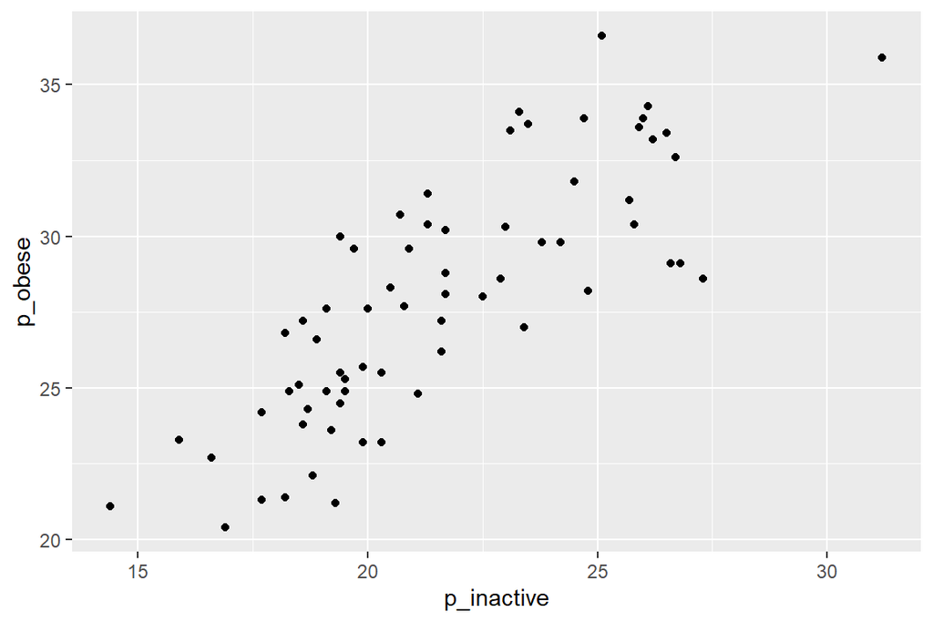

```r
ggplot( NE.data, aes(x = p_inactive, y = p_obese)) + geom_point()
```

### Histogram

**Variation** - tendency of the variable values to change from observation to observation. Each measurement of a variable includes a small amount of error that varies from one observation to another. To better understand the pattern in variation is to display the variable’s distribution

For a continuous variable, we use a *histogram*:

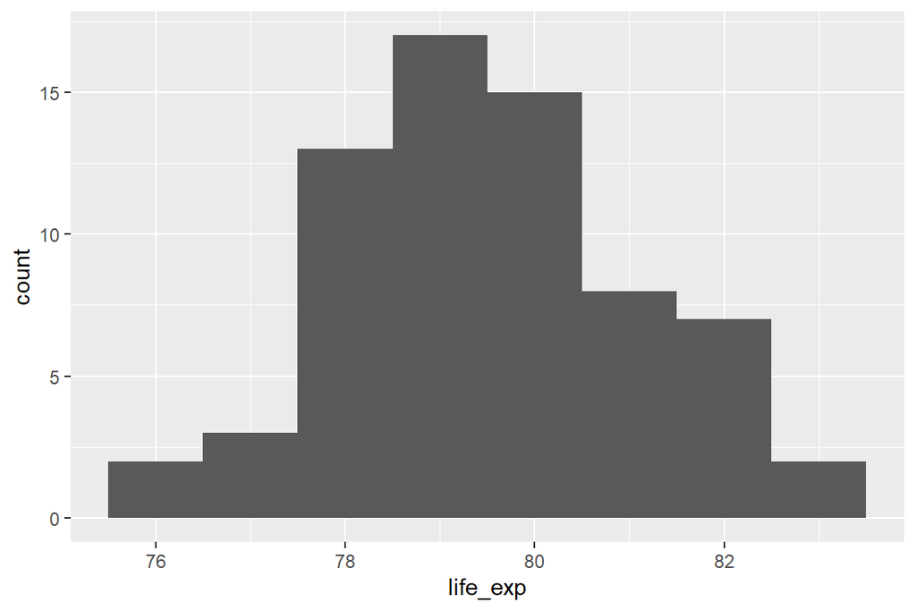

```r
ggplot( NE.data, aes (x = life_exp) ) + geom_histogram( binwidth = 1)
```

Let’s take a look at another variable - *N_rural*

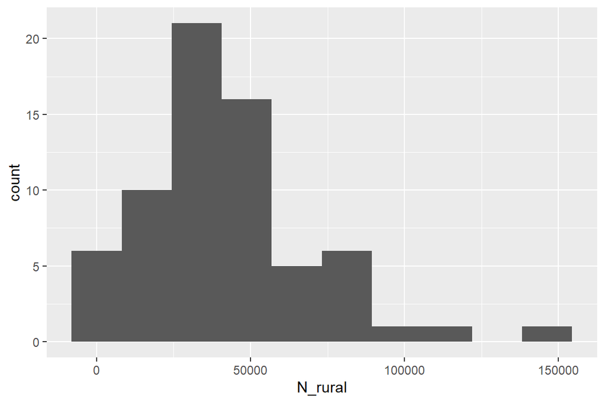

```r
ggplot( NE.data, aes (x = N_rural) ) + geom_histogram( bins = 10 )
```

We can see here that this variable is not normally distributed, There are very few counties with a very small number of rural areas. Majority of counties have about 30K rural households. But this graph has a very long right tail - there are some few counties that have about 150K rural households.

When we look at a histogram, we should ask the following questions:

- Which values are most common and why?
- Which values are most rare and why?
- How many clusters are there in the graph?
- How many observations in each cluster?
- Can we explain these clusters?
- Are there any unusual values?

Let’s take a look at the distribution of *p_inactive* variable:

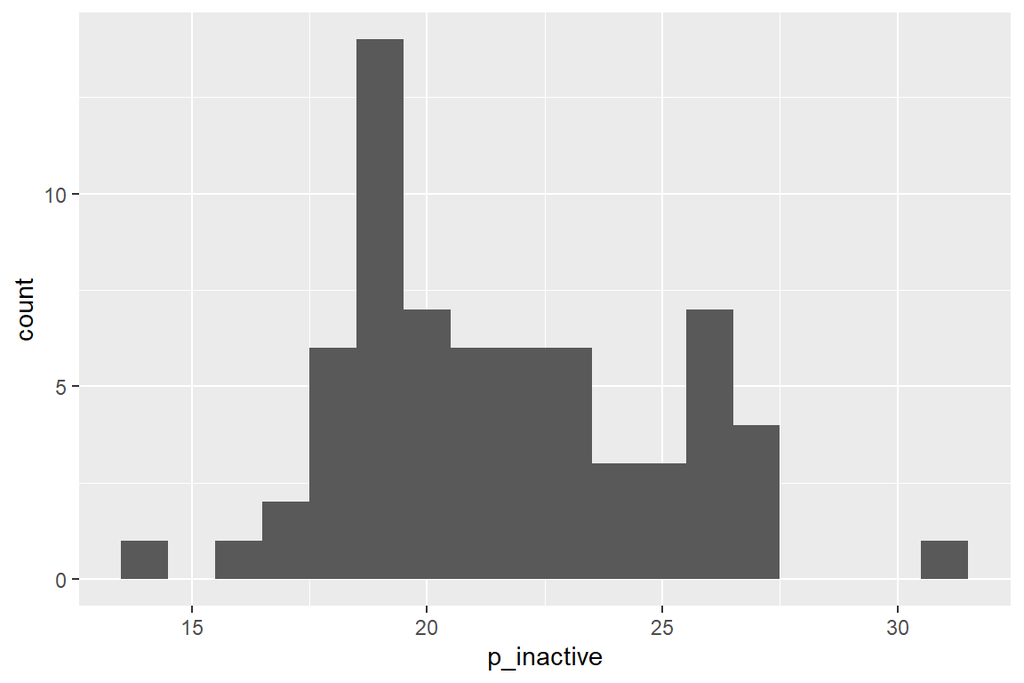

```r
ggplot( NE.data, aes (x = p_inactive) ) + geom_histogram( binwidth = 1 )
```

We might want to explore, which county has more than 30% of inactive adults (and why):

```r
NE.data %>% filter (p_inactive > 30)
```

| State | County | poor_health | p_smokers | p_obese | p_inactive | p_college | p_housing_problems | life_exp | ph_distress | limit_healthy_food | house_income | Population | N_black | N_rural |
| --- | --- | --- | --- | --- | --- | --- | --- | --- | --- | --- | --- | --- | --- | --- |
| Maine | Aroostook | 17.49279 | 18.59272 | 35.9 | 31.2 | 65.29889 | 13.66834 | 77.98312 | 12.40331 | 4.683477 | 39450 | 67111 | 695 | 57687 |

We can see that this is Aroostook County in Maine - the largest American county by land east of the Mississippi River (it is larger than three USA States!) Now, once we identify the observation, we can further explore information we have to understand why percentage of inactive adults is so high in this county.

#### **Exercise**

Plot histograms for *house_income* and *p_housing_problems*. Select appropriate bandwidth for each histogram and compare the shapes.

### Boxplot

Another useful tool to explore the variable variation is a boxplot.

Boxplot graph shows:

- median value
- maximum and minimum values in a variable and potential outliers
- interquartile range
- 25th and 75th percentile values

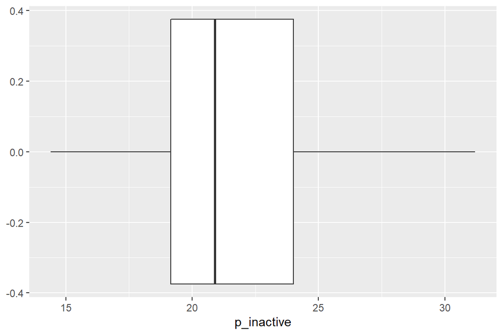

```r
ggplot( NE.data, aes (x = p_inactive) ) + geom_boxplot()
```

We can compare the variation of this variable across various states:

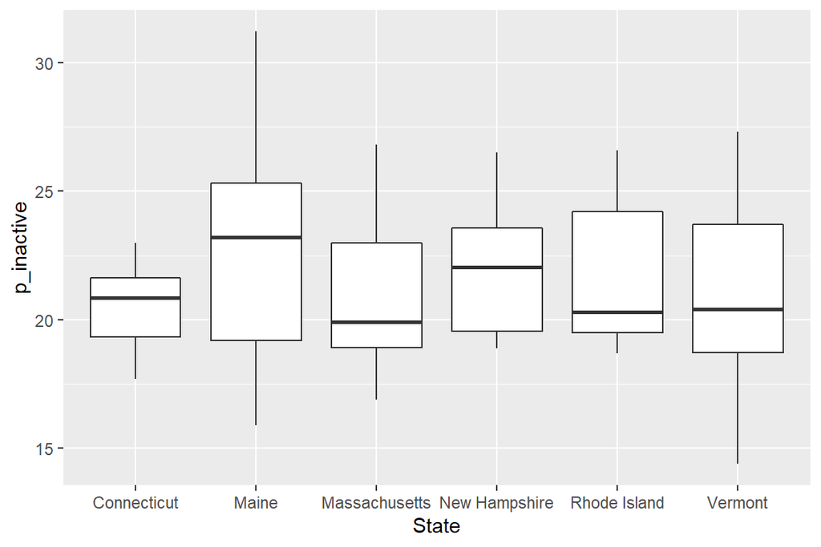

```r
ggplot( NE.data, aes (x = State, y = p_inactive) ) + geom_boxplot()
```

Boxplot however hides the distribution within a box. So sometimes it is useful to display the actual values within boxplot. We can do that by adding *geom_jitter*:

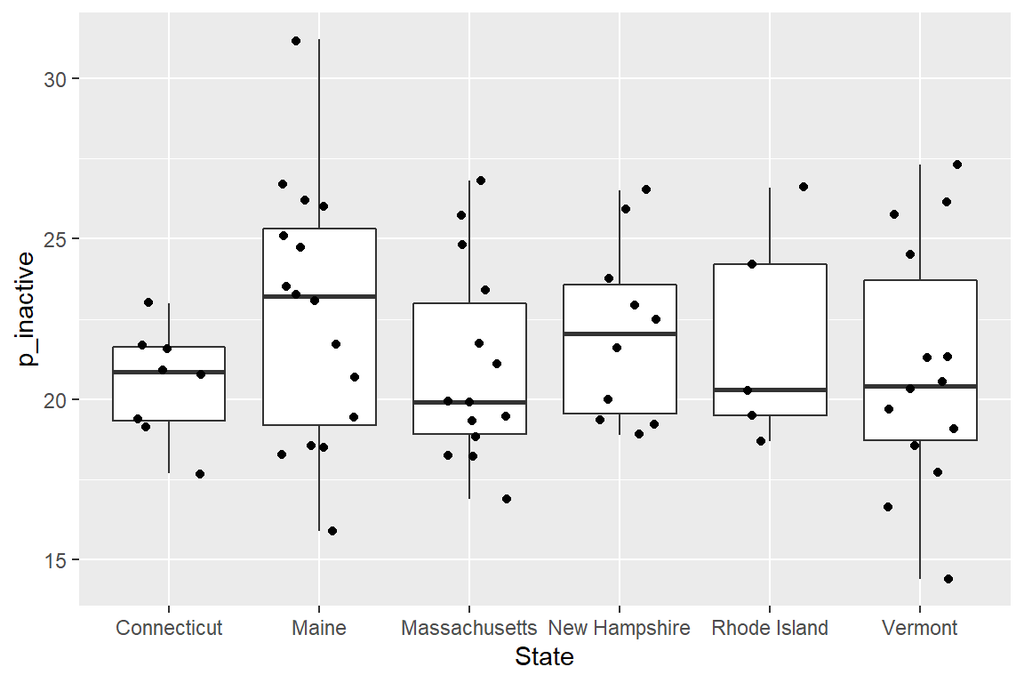

```r
ggplot( NE.data, aes (x = State, y = p_inactive) ) +
  geom_boxplot() +
  geom_jitter( width = .25)
```

The above plot allows us to better see the variable’s distribution within each state

#### **Exercise**

Plot boxplots for *life_exp* per State. Use *geom_jitter()* to better see the distribution of the variable within each boxplot.

### Violin plot

Another way to compare shapes of distributions of a continuous variable is to use a violin plot:

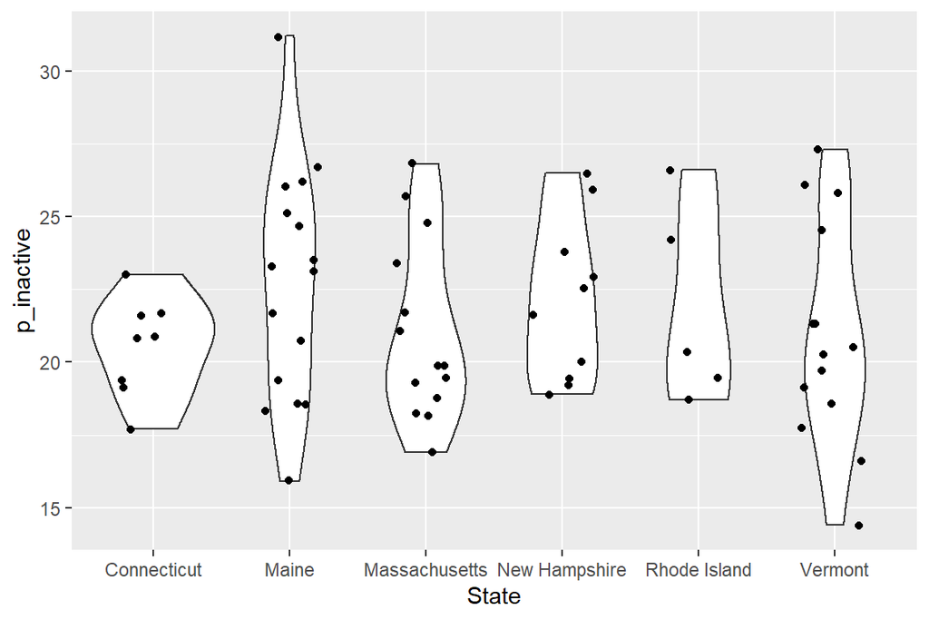

```r
ggplot( NE.data, aes (x = State, y = p_inactive) ) +
  geom_violin() +
  geom_jitter( width = .25)
```

### Bar chart

To explore the distribution of a categorical variable, use a bar chart. In our dataset, State is a categorical variable. Using a bar chart we can compare the number of Counties within each State

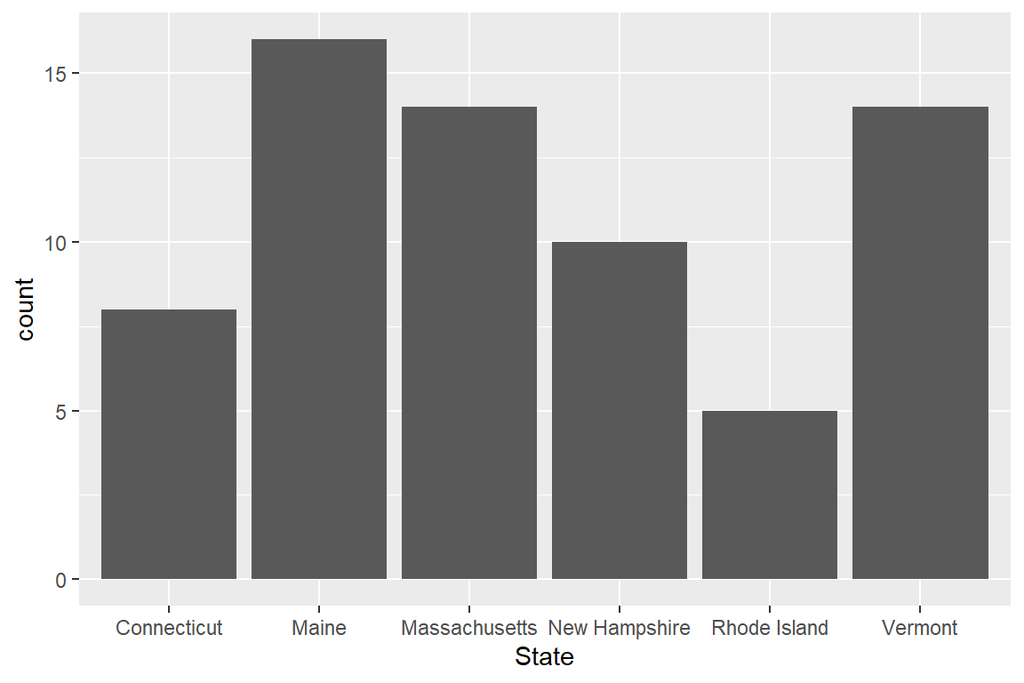

```r
ggplot( NE.data, aes (x = State) ) +
  geom_bar()
```

### Scatterplot

To explore the relationship between two numeric variables, we can use a scatterplot

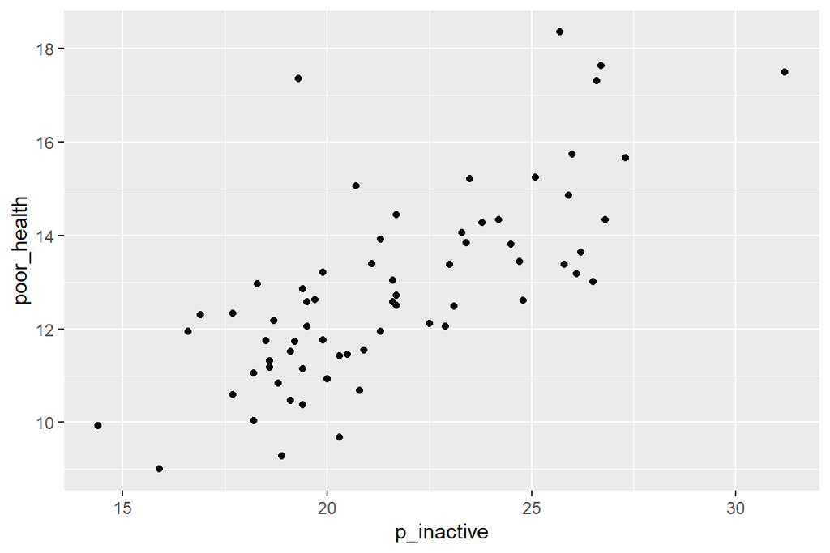

```r
ggplot( NE.data, aes(x = p_inactive, y = poor_health)) + geom_point()
```

It seems that there some positive correlationship between these two variables. Let’s try to add a linear regression line:

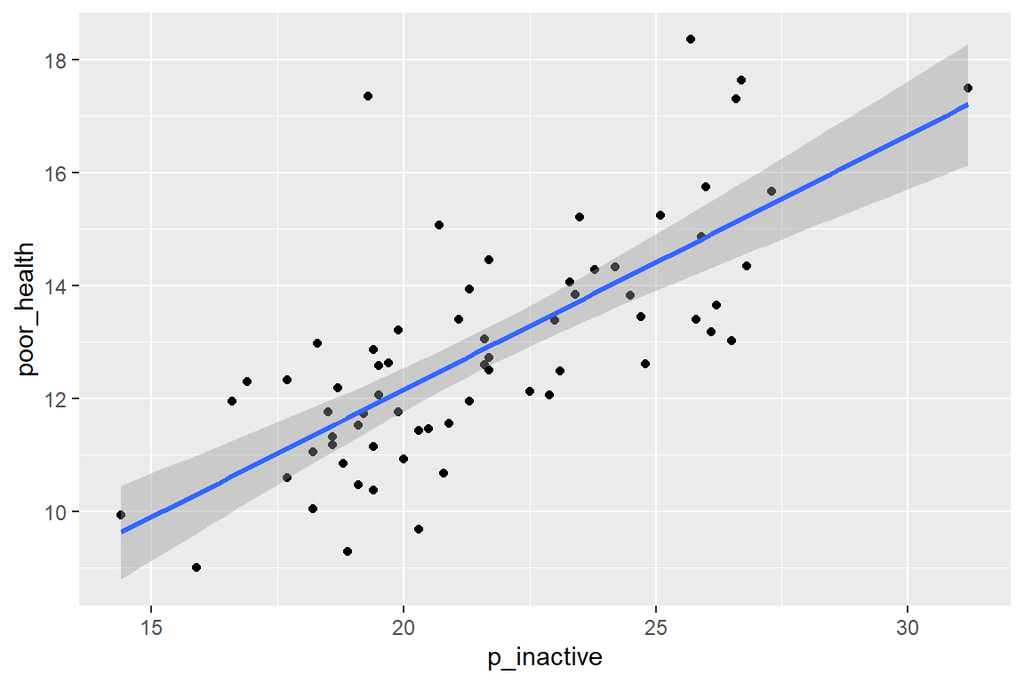

```r
ggplot( NE.data, aes(x = p_inactive, y = poor_health)) +
  geom_point() +
  geom_smooth ( method = lm )
```

#### **Exercise**

Create scatterplots between for *life_exp* and *ph_distress*. Add a linear regression line to your plot.

## Communicating your story with plots

Now, when we are familiar with basic ggplot2 syntax and plots, let’s improve our plots to learn more from our data and better communicate the results to others.

We will use the full dataset that includes all USA States:

```r
USA.health <- read_csv("https://github.com/bu-rcs/bu-rcs.github.io/raw/main/Bootcamp/Data/USA_HealthData.csv") %>%
  rename(poor_health = "% Fair or Poor Health",
         p_smokers = "% Smokers",
         p_obese = "% Adults with Obesity",
         p_inactive = "% Physically Inactive",
         p_college="% Some College",
         p_housing_problems = "% Severe Housing Problems") %>%
  select(State, County, poor_health : p_inactive, p_college, p_housing_problems) %>%
  filter( !is.na(County) )



USA.demogr <- read_csv("https://github.com/bu-rcs/bu-rcs.github.io/raw/main/Bootcamp/Data/USA_DemographicsData.csv") %>%
  rename( life_exp = "Life Expectancy",
          ph_distress = "% Frequent Physical Distress",
          limit_healthy_food = "% Limited Access to Healthy Foods",
          house_income = "Median Household Income",
          N_black = "# Black",
          N_rural = "# Rural") %>%
  select(State : house_income, Population, N_black, N_rural) %>%
  filter( !is.na(County) )


USA.data <- inner_join( USA.health, USA.demogr, by = c("State", "County"))


USA.regions <- read_csv("https://github.com/bu-rcs/bu-rcs.github.io/raw/main/Bootcamp/Data/us_states_census_regions.csv")

# Add the names of Regions
USA.data <- merge(USA.data, USA.regions, by = "State")

glimpse (USA.data)    # similar to str() but slightly different format of output
```

```
## Rows: 3,142
## Columns: 16
## $ State              <chr> "Alabama", "Alabama", "Alabama", "Alabama", "Ala...
## $ County             <chr> "Autauga", "Baldwin", "Barbour", "Bibb", "Blount...
## $ poor_health        <dbl> 20.88299, 17.50913, 29.59180, 19.43972, 21.74529...
## $ p_smokers          <dbl> 18.08156, 17.48903, 21.99998, 19.11420, 19.20867...
## $ p_obese            <dbl> 33.3, 31.0, 41.7, 37.6, 33.8, 37.2, 43.3, 38.5, ...
## $ p_inactive         <dbl> 34.7, 26.5, 23.5, 33.5, 30.3, 24.6, 39.5, 31.7, ...
## $ p_college          <dbl> 62.00997, 67.37162, 34.85765, 44.13735, 53.36107...
## $ p_housing_problems <dbl> 14.663462, 13.566201, 14.583333, 10.496454, 10.5...
## $ life_exp           <dbl> 76.87948, 78.45026, 75.34193, 73.57182, 74.14583...
## $ ph_distress        <dbl> 13.68523, 12.48011, 17.18490, 13.62658, 14.52316...
## $ limit_healthy_food <dbl> 11.9911250, 5.4244266, 10.7396666, 2.6016270, 2....
## $ house_income       <dbl> 59338, 57588, 34382, 46064, 50412, 29267, 37365,...
## $ Population         <dbl> 55601, 218022, 24881, 22400, 57840, 10138, 19680...
## $ N_black            <dbl> 10755, 19151, 11951, 4731, 846, 7050, 8769, 2382...
## $ N_rural            <dbl> 22921, 77060, 18613, 15663, 51562, 5607, 14921, ...
## $ Region             <chr> "East South Ctr", "East South Ctr", "East South ...
```

### Adding Title and axis labels to the plot

We will start with a simple scatterplot

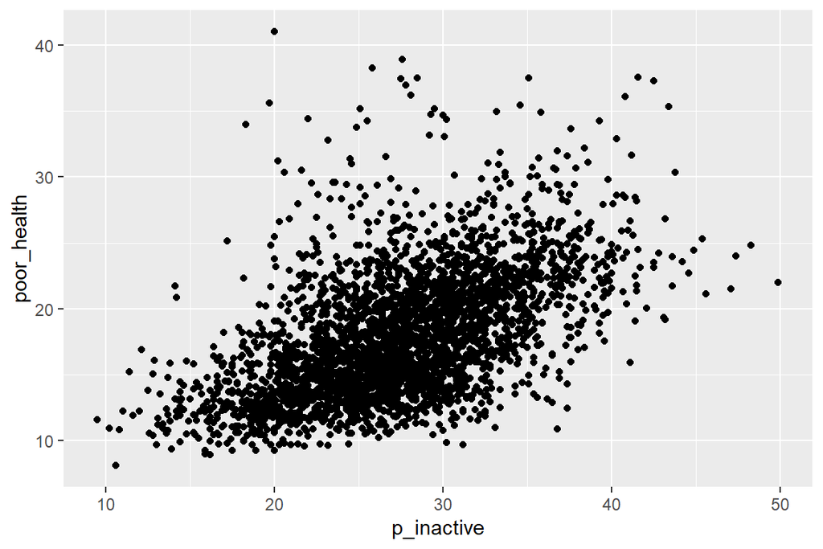

```r
ggplot( USA.data, aes(x = p_inactive, y = poor_health)) + geom_point()
```

In this plot we would like to add a title and change labels for x and y axes. We can do it in two ways:

```r
ggplot( USA.data, aes(x = p_inactive, y = poor_health)) +
  geom_point() +
  ggtitle ("Adults with Poor Health vs.Physically Inactive") +
  xlab( "Physically Inactive (%)") +
  ylab( "Poor Health (%)")
```

or

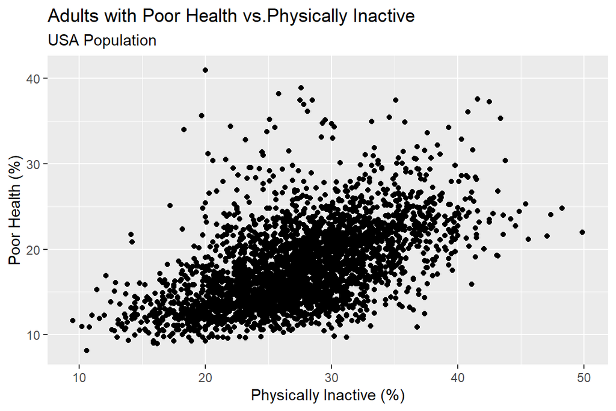

```r
ggplot( USA.data, aes(x = p_inactive, y = poor_health)) +
  geom_point() +
  labs( title = "Adults with Poor Health vs.Physically Inactive",
        subtitle="USA Population",
        x =  "Physically Inactive (%)",
        y = "Poor Health (%)")
```

There are so many points on this plot that it is hard to estimate the number of points in the middle of the plot. We can add transparency when we plot the points

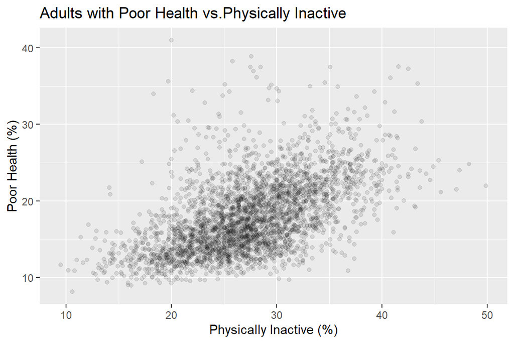

```r
ggplot( USA.data, aes(x = p_inactive, y = poor_health)) +
  geom_point(alpha = 0.1) +
  labs( title = "Adults with Poor Health vs.Physically Inactive",
        x =  "Physically Inactive (%)",
        y = "Poor Health (%)")
```

Sometimes it is useful to change the limits of x and/or y axes:

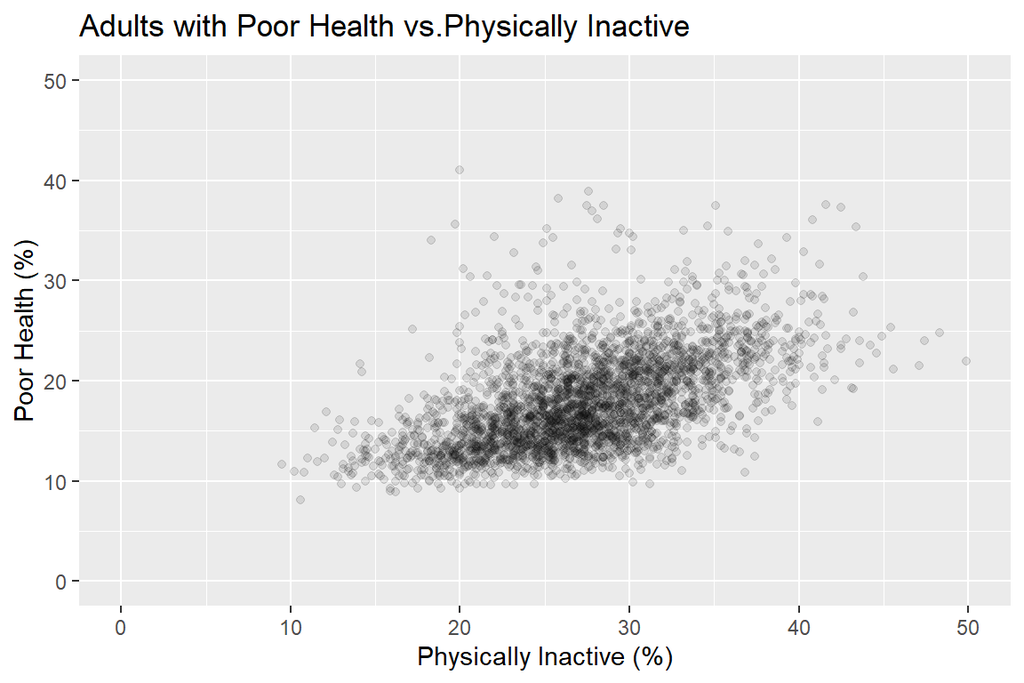

```r
ggplot( USA.data, aes(x = p_inactive, y = poor_health)) +
  geom_point(alpha = 0.1) +
  labs( title = "Adults with Poor Health vs.Physically Inactive",
        x =  "Physically Inactive (%)",
        y = "Poor Health (%)") +
  xlim(0,50) +
  ylim(0,50)
```

Together with the regression line:

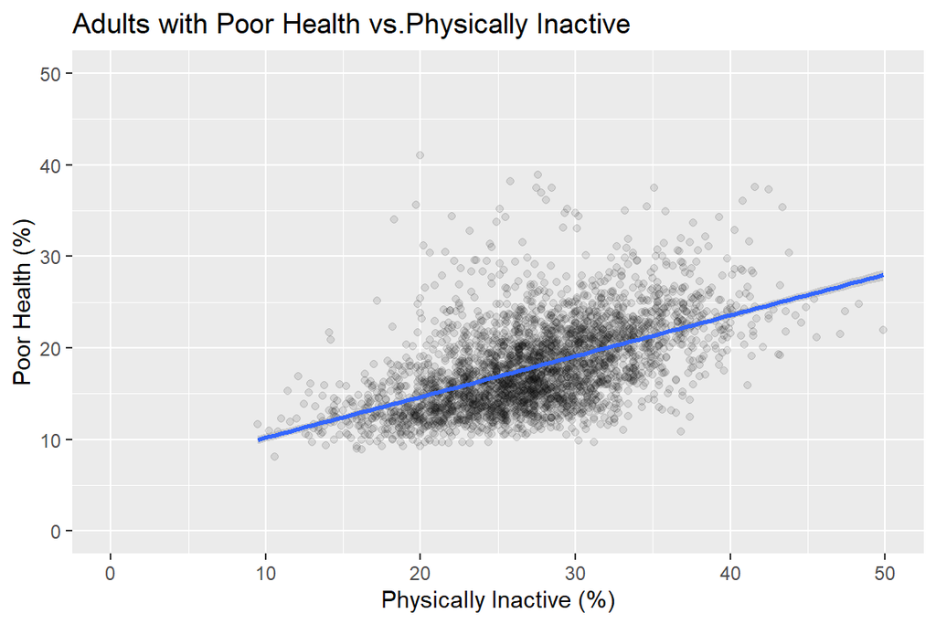

```r
ggplot( USA.data, aes(x = p_inactive, y = poor_health)) +
  geom_point(alpha = 0.1) +
  geom_smooth(method="lm")+
  labs( title = "Adults with Poor Health vs.Physically Inactive",
        x =  "Physically Inactive (%)",
        y = "Poor Health (%)") +
  xlim(0,50) +
  ylim(0,50)
```

#### **Exercise**

Create scatterplots between for *life_exp* and *ph_distress*. Add a title and axes labels to your plot.

### Barplots

Sometimes there is a need to compare two or more groups of populations. Let’s create a categorical variable. We will assign a label to each County based on the median household income.

```r
USA.data_extra <- USA.data %>%
  mutate( wealth = case_when(house_income < 50000 ~ "low",
                             house_income > 80000 ~ "high",
                             TRUE ~ "middle"))

table(USA.data_extra$wealth)
```

```
##
##   high    low middle
##    155   1497   1490
```

Let’s calculate USA population living in counties with low, middle and high income

```r
res <- USA.data_extra %>%
  group_by(wealth) %>%
  summarise ( pop = sum(Population) / 1000000 )  # in Millions
res
```

| wealth | pop |
| --- | --- |
| high | 60.88569 |
| low | 58.68082 |
| middle | 207.60092 |

We can now use this table to draw a barplot:

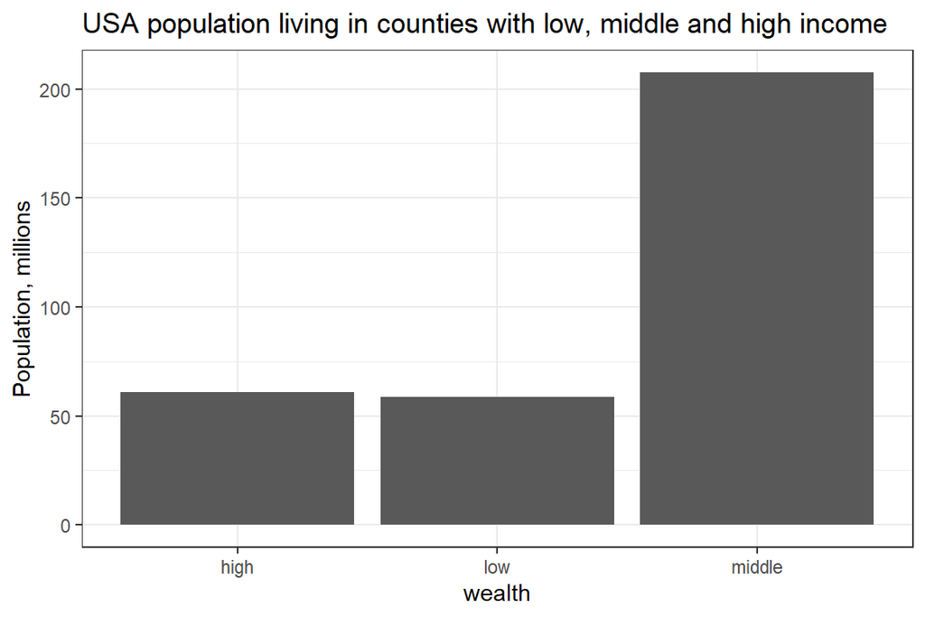

```r
ggplot(res, aes(x=wealth, y = pop )) +
  geom_bar( stat = "identity" ) +
  ggtitle ( "USA population living in counties with low, middle and high income" ) +
  ylab("Population, millions") +
  theme_bw()   # add black and white theme
```

Sometimes it is useful to add values on top of each bar.

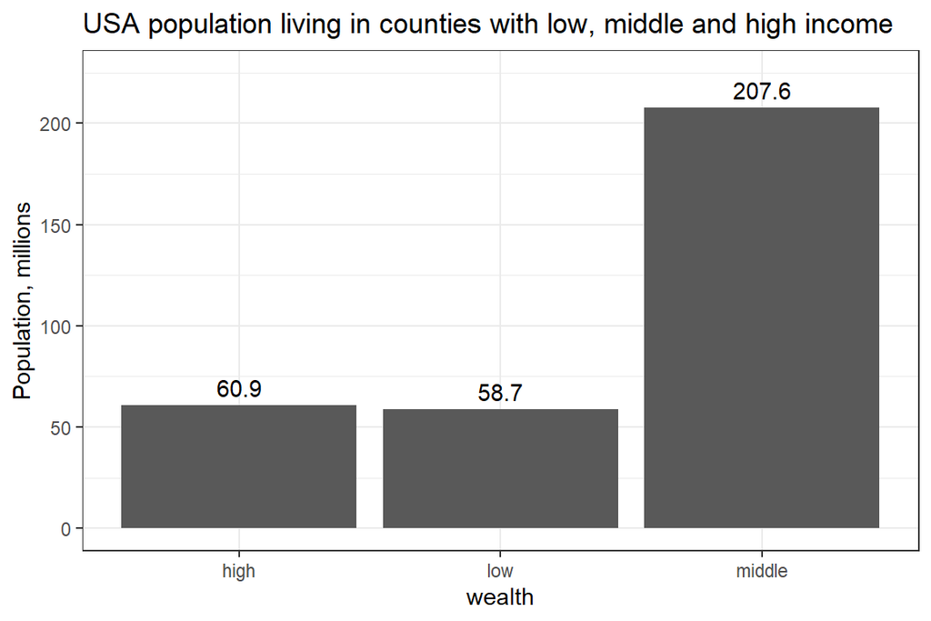

```r
ggplot(res, aes(x=wealth, y = pop )) +
  geom_bar( stat = "identity" ) +
  geom_text( aes (label = round(pop, 1) ), vjust = -0.5) +
  ggtitle ( "USA population living in counties with low, middle and high income" ) +
  ylab("Population, millions") +
  ylim(0, 225) +
  theme_bw()   # add black and white theme
```

#### **Exercise**

Compute population living in each USA region and display in as a bar graph. Add `coord_flip()` function to flip x and y axes.

### Grouped Barcharts

We would like to split each bar into groups using a categorical variable. For example compare population living in type of community within each Region. We can create a table using two variables in the group_by function:

```r
res <- USA.data_extra %>%
  group_by(Region, wealth) %>%
  summarise ( pop = sum(Population) / 1000000 )  # in Millions
res
```

| Region | wealth | pop |
| --- | --- | --- |
| East North Ctr | high | 5.977848 |
| East North Ctr | low | 9.537332 |
| East North Ctr | middle | 31.416703 |
| East South Ctr | high | 0.316993 |
| East South Ctr | low | 9.859898 |
| East South Ctr | middle | 8.935922 |
| Mid. Atl. | high | 12.842839 |
| Mid. Atl. | low | 5.046524 |
| Mid. Atl. | middle | 23.368426 |
| New. Eng | high | 4.590991 |

[output cut: 11 more lines]

Now we will use a *fill* argument in the `aes()` call. We will also add a `position="dodge"` to the `geom_bar()` call:

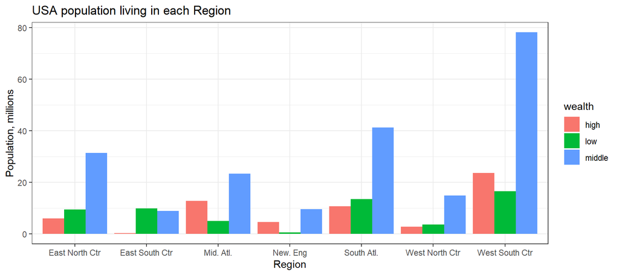

```r
ggplot(res, aes(x=Region, y = pop, fill = wealth )) +
  geom_bar( position="dodge", stat = "identity" ) +
  ggtitle ( "USA population living in each Region" ) +
  ylab("Population, millions") +
  theme_bw()   # add black and white theme
```

New England has less population than West South Ctr Region. So it is hard to compare the relationship of three groups. We can modify the plot to “percent stacked” barchart. The only modification we need to mak is to set `position="fill"` in the `geom_bar()` call:

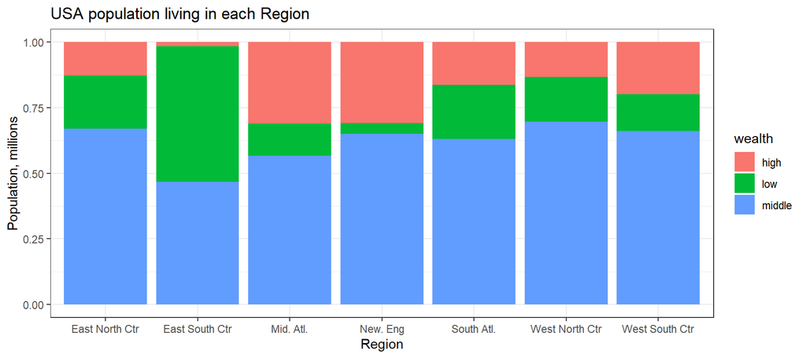

```r
ggplot(res, aes(x=Region, y = pop, fill = wealth )) +
  geom_bar( position="fill", stat = "identity" ) +
  ggtitle ( "USA population living in each Region" ) +
  ylab("Population, millions") +
  theme_bw()   # add black and white theme
```

In some cases it is useful to display each set of bars in its own plot. To do this we can add `facet_wrap()` function. We will also set `x=wealth` in the `aes()` call:

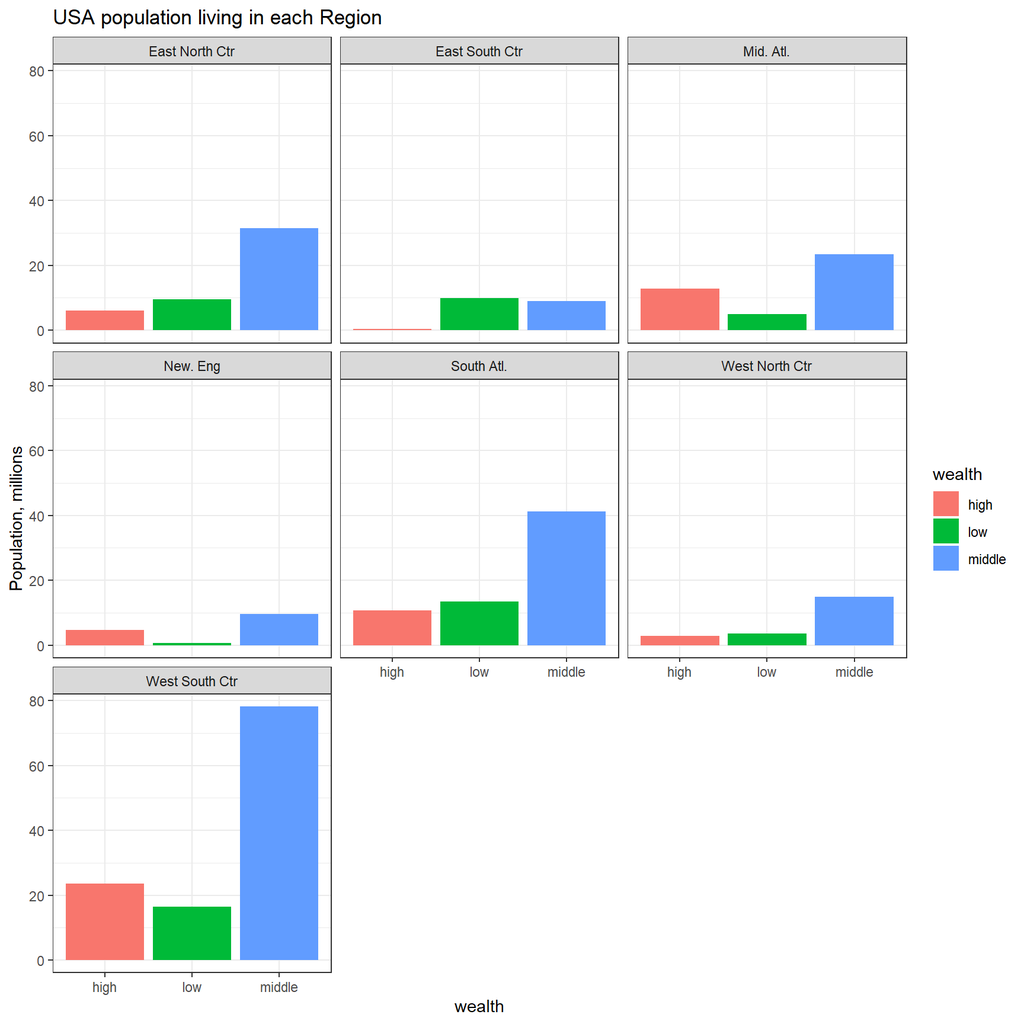

```r
ggplot(res, aes(x=wealth, y = pop, fill = wealth )) +
  geom_bar( position="dodge", stat = "identity" ) +
  facet_wrap(~Region) +
  ggtitle ( "USA population living in each Region" ) +
  ylab("Population, millions") +
  theme_bw()   # add black and white theme
```

#### **Exercise**

Use `facet_wrap()` function to compare distributions (using histograms) of *ph_distress* variable from *USA.data* dataset for different regions.

#### Read more:

- [ggplot2 tutorial](http://r-statistics.co/Complete-Ggplot2-Tutorial-Part1-With-R-Code.html)
- [ggplot2 cheat sheet](https://github.com/rstudio/cheatsheets/blob/master/data-visualization-2.1.pdf)
- [R graph gallery](https://www.r-graph-gallery.com/)
- [ggplot2 extensions](https://exts.ggplot2.tidyverse.org/gallery/)

### Homework

1. Using violin plot explore the distribution of p_smokers variable per Region.
2. Add geom_jitter to better see the distribution of values for each region
3. Plot *life_exp* variable vs. *p_smokers*. Add title and modify the axes labels to make the graph more clear
4. Which State has a county with the life_exp value greater than 100? Explore the demographics in this region.

### Apendix

There are many useful ggplot2 extension. Here are just a few examples

using `install.packages("ggExtra")` command install *ggExtra* package

Now we can add marginal distributions to the axes of our plot

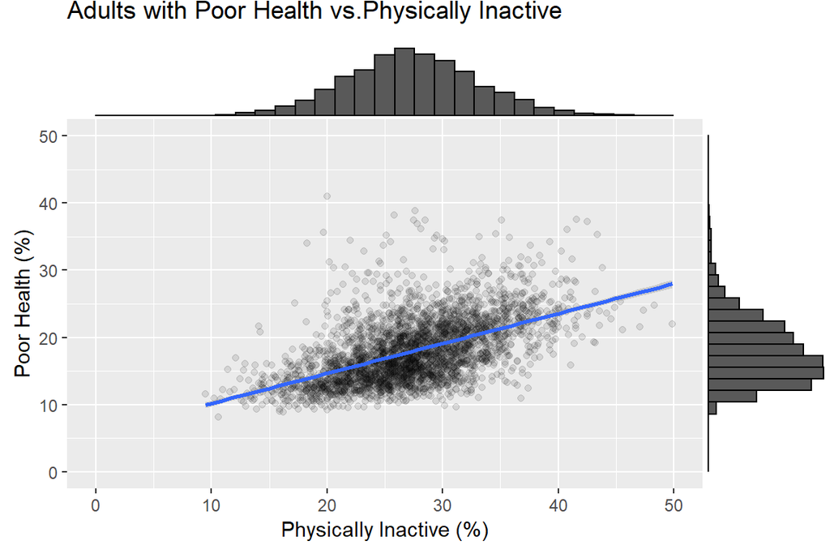

```r
library(ggExtra)
g <- ggplot( USA.data, aes(x = p_inactive, y = poor_health)) +
  geom_point(alpha = 0.1) +
  geom_smooth(method="lm")+
  labs( title = "Adults with Poor Health vs.Physically Inactive",
        x =  "Physically Inactive (%)",
        y = "Poor Health (%)") +
  xlim(0,50) +
  ylim(0,50)

  ggMarginal (g, type="histogram" )
```

You can try to set *type* argument in the *ggMarginal* function to be *density* or *boxplot* to display the distribution as a density curve or a boxplot respectfully.

### Scatterplot Matrix

When we start exploring the dataset it might be useful to quickly look at the reletionship of all numeric variables. We can use a scatterplot matrix.

using `install.packages("GGally")` command install *GGally* package

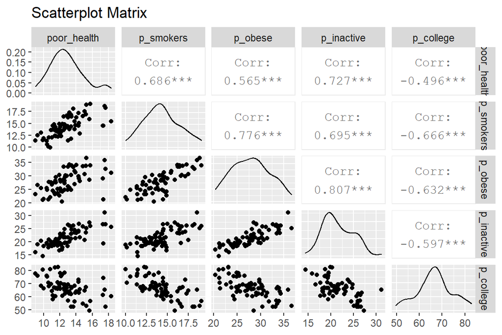

```r
library(GGally)

ggpairs(NE.data[, 3:7], title="Scatterplot Matrix")
```